# Assignment 3 - Working with Data & Data Relations

2030071 - 1753320

Group 50: Romée Simons and Tycho Brouwer

2024-03-10

# Task 1

```r
education_data <- read_delim('education_data.csv', delim=";", show_col_types = FALSE)
```

# Task 2

According to the glimpse function the dataset has 6 columns and 132 rows.

From manually inspecting the data, the column **value** is missing a data for 33 rows.

The period of the data is from 2011 to 2022, the values range from 14380 to 64990, so the range is 50610.

```
## Rows: 132
## Columns: 6
## $ meAsur3       <chr> "Gediplomeerden", "Gediplomeerden", "Gediplomeerden", "G…
## $ gender_coded  <chr> "T001038", "T001038", "T001038", "T001038", "T001038", "…
## $ EducationType <chr> "Hoger beroepsonderwijs", "Hoger beroepsonderwijs", "Hog…
## $ degreeType    <chr> "Bachelor", "Bachelor", "Bachelor", "Bachelor", "Bachelo…
## $ Period        <chr> "2011/'12", "2012/'13", "2013/'14", "2014/'15", "2015/'1…
## $ VALUE         <dbl> 55240, 51370, 53400, 57250, 58920, 62530, 64190, 62210, …
```

# Task 3

```r
education_data <- education_data |>
  rename(
    measure = meAsur3,
    gender_code = gender_coded,
    education_type = EducationType,
    degree_type = degreeType,
    period = Period,
    graduates = VALUE
    )

glimpse(education_data)
```

```
## Rows: 132
## Columns: 6
## $ measure        <chr> "Gediplomeerden", "Gediplomeerden", "Gediplomeerden", "…
## $ gender_code    <chr> "T001038", "T001038", "T001038", "T001038", "T001038", …
## $ education_type <chr> "Hoger beroepsonderwijs", "Hoger beroepsonderwijs", "Ho…
## $ degree_type    <chr> "Bachelor", "Bachelor", "Bachelor", "Bachelor", "Bachel…
## $ period         <chr> "2011/'12", "2012/'13", "2013/'14", "2014/'15", "2015/'…
## $ graduates      <dbl> 55240, 51370, 53400, 57250, 58920, 62530, 64190, 62210,…
```

# Task 4

```r
typeof(education_data$measure)
```

```
## [1] "character"
```

```r
typeof(education_data$gender_code)
```

```
## [1] "character"
```

```r
typeof(education_data$education_type)
```

```
## [1] "character"
```

```r
typeof(education_data$degree_type)
```

```
## [1] "character"
```

```r
typeof(education_data$period)
```

```
## [1] "character"
```

```r
typeof(education_data$graduates)
```

```
## [1] "double"
```

The columns for the **measure**, **gender code**, **education type**, **degree type**, and **period** are of the type **character**.

The **value** column has a datatype of **double**.

# Task 5

```r
gender_code_data = tribble(
  ~gender_code, ~gender,
  "T001038", "Total",
  "3000", "Men",
  "4000", "Women",
  "5000", "Other",
  "6000", "prefer_not_to_say",
)

gender_code_data
```

```
## # A tibble: 5 × 2
##   gender_code gender
##   <chr>       <chr>
## 1 T001038     Total
## 2 3000        Men
## 3 4000        Women
## 4 5000        Other
## 5 6000        prefer_not_to_say
```

# Task 6

The primary dataset is the data from the **education_data.csv** file.

From both datasets all rows are unique, unique returns the same number of columns.

From the second dataset we want to incorporate the gender column.

```r
unique(education_data)
```

```
## # A tibble: 132 × 6
##    measure        gender_code education_type        degree_type period graduates
##    <chr>          <chr>       <chr>                 <chr>       <chr>      <dbl>
##  1 Gediplomeerden T001038     Hoger beroepsonderwi… Bachelor    2011/…     55240
##  2 Gediplomeerden T001038     Hoger beroepsonderwi… Bachelor    2012/…     51370
##  3 Gediplomeerden T001038     Hoger beroepsonderwi… Bachelor    2013/…     53400
##  4 Gediplomeerden T001038     Hoger beroepsonderwi… Bachelor    2014/…     57250
##  5 Gediplomeerden T001038     Hoger beroepsonderwi… Bachelor    2015/…     58920
##  6 Gediplomeerden T001038     Hoger beroepsonderwi… Bachelor    2016/…     62530
##  7 Gediplomeerden T001038     Hoger beroepsonderwi… Bachelor    2017/…     64190
##  8 Gediplomeerden T001038     Hoger beroepsonderwi… Bachelor    2018/…     62210
##  9 Gediplomeerden T001038     Hoger beroepsonderwi… Bachelor    2019/…     61690
## 10 Gediplomeerden T001038     Hoger beroepsonderwi… Bachelor    2020/…     64990
## # ℹ 122 more rows
```

```r
unique(gender_code_data)
```

```
## # A tibble: 5 × 2
##   gender_code gender
##   <chr>       <chr>
## 1 T001038     Total
## 2 3000        Men
## 3 4000        Women
## 4 5000        Other
## 5 6000        prefer_not_to_say
```

# Task 7

With the join operation the **gender** column has been added to the dataset.

```r
joined_data = inner_join(education_data, gender_code_data)

glimpse(joined_data)
```

```
## Rows: 132
## Columns: 7
## $ measure        <chr> "Gediplomeerden", "Gediplomeerden", "Gediplomeerden", "…
## $ gender_code    <chr> "T001038", "T001038", "T001038", "T001038", "T001038", …
## $ education_type <chr> "Hoger beroepsonderwijs", "Hoger beroepsonderwijs", "Ho…
## $ degree_type    <chr> "Bachelor", "Bachelor", "Bachelor", "Bachelor", "Bachel…
## $ period         <chr> "2011/'12", "2012/'13", "2013/'14", "2014/'15", "2015/'…
## $ graduates      <dbl> 55240, 51370, 53400, 57250, 58920, 62530, 64190, 62210,…
## $ gender         <chr> "Total", "Total", "Total", "Total", "Total", "Total", "…
```

# Task 8

```r
table1 = tribble(
  ~Year, ~Program, ~Value,
  2019, "uni_master", 41710,
  2020, "uni_master", 46810,
  2021, "uni_master", 46870,
)

table2 = tribble(
  ~Year, ~Program, ~Value,
  2018, "uni_master", 40860,
  2020, "uni_master", 46810,
  2021, "uni_master", 46870,
)

table3 = tribble(
  ~Year, ~`Total people`,
  2018, 17181084,
  2019, 17282163,
  2020, 17407585,
  2021, 17475415,
)
```

table 1:

| Year | Program | Value |
| --- | --- | --- |
| 2019 | uni_master | 41710 |
| 2020 | uni_master | 46810 |
| 2021 | uni_master | 46870 |

table 2:

| Year | Program | Value |
| --- | --- | --- |
| 2018 | uni_master | 40860 |
| 2020 | uni_master | 46810 |
| 2021 | uni_master | 46870 |

table 3:

| Year | Total people |
| --- | --- |
| 2018 | 17181084 |
| 2019 | 17282163 |
| 2020 | 17407585 |
| 2021 | 17475415 |

# Task 9

Unique combination of table 1 and table 2:

| Year | Program | Value |
| --- | --- | --- |
| 2019 | uni_master | 41710 |
| 2020 | uni_master | 46810 |
| 2021 | uni_master | 46870 |
| 2018 | uni_master | 40860 |

With total people added:

[output not shown]

Duplicate rows from table 1 and table 2

| Year | Program | Value |
| --- | --- | --- |
| 2020 | uni_master | 46810 |
| 2021 | uni_master | 46870 |

# Task 10

```r
education_lvl_data <- read_delim('education_level_data.csv', delim=",", show_col_types = FALSE, skip = 3)

summary(education_lvl_data)
```

```
##       year         degree              value
##  Min.   :2011   Length:44          Min.   :31250
##  1st Qu.:2013   Class :character   1st Qu.:34870
##  Median :2016   Mode  :character   Median :40860
##  Mean   :2016                      Mean   :44617
##  3rd Qu.:2019                      3rd Qu.:55240
##  Max.   :2021                      Max.   :64990
##                                    NA's   :11
```

# Task 11

According to the following graph, the number of HBO bachelor graduates are far greater than the other degrees over the years. After that, there are most WO Master graduates and WO Bachelor graduates. Data about HBO Master graduates are not in the graph. For WO Bachelors and WO Masters there is increase in the number of graduates over the years. For HBO Bachelors there is and increase up to around 2017, then a decrease and then again an increase of the number of graduates. However overall this the number of graduates of the HBO Bachelor has also grown.

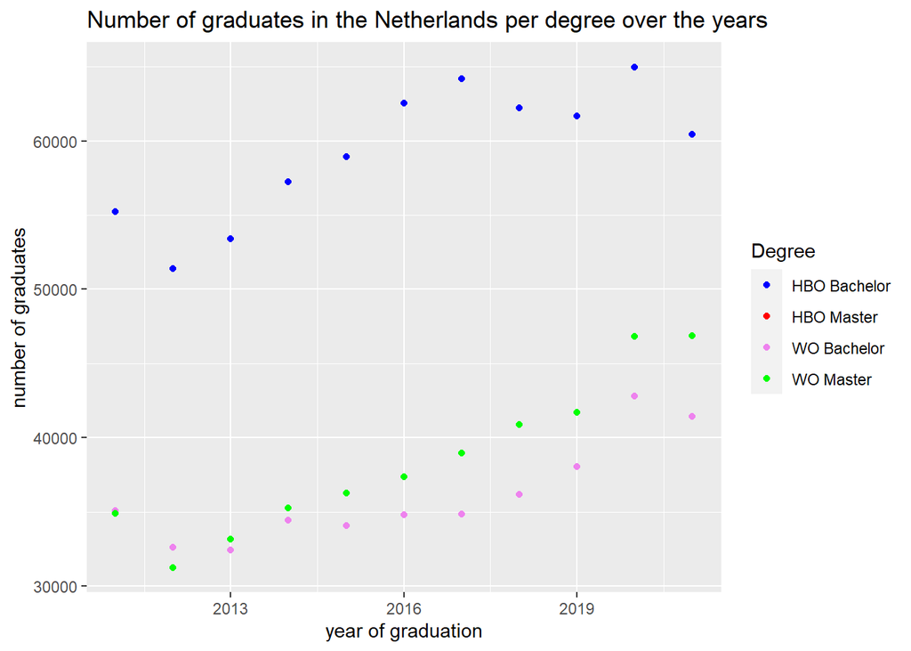

```r
education_lvl_data |>
  ggplot(aes(`year`, `value`, colour = degree)) +
  geom_point() +
  labs(x = 'year of graduation', y = 'number of graduates') +
  ggtitle('Number of graduates in the Netherlands per degree over the years') +
  scale_color_manual(name="Degree", labels = c("HBO Bachelor", "HBO Master", "WO Bachelor", "WO Master"), values = c("blue", "red", "violet", "green"))
```